# Shopify Challenge problems

Tinglei Wu

1/18/2022

```r
library(tidyverse)
library(dplyr)
library(ggplot2)

shopify_dataset <- read_csv('2019 Winter Data Science Intern Challenge Data Set - Sheet1.csv')
```

```r
head(shopify_dataset)
```

```
## # A tibble: 6 × 7
##   order_id shop_id user_id order_amount total_items payment_method created_at
##      <dbl>   <dbl>   <dbl>        <dbl>       <dbl> <chr>          <chr>
## 1        1      53     746          224           2 cash           2017-03-13 1…
## 2        2      92     925           90           1 cash           2017-03-03 1…
## 3        3      44     861          144           1 cash           2017-03-14 4…
## 4        4      18     935          156           1 credit_card    2017-03-26 1…
## 5        5      18     883          156           1 credit_card    2017-03-01 4…
## 6        6      58     882          138           1 credit_card    2017-03-14 1…
```

```r
order_amount_each_store <- shopify_dataset %>%
  select(shop_id, order_amount)%>% # select only shop_id and order_amount columns
  group_by(shop_id)%>% # group by shop_id
  summarise(total_order_amount = sum(order_amount))%>% #calculating the sum of total order amount for each of the 100 shop
  arrange(desc(total_order_amount)) # arrange the total order amount in descending order

order_amount_each_store
```

```
## # A tibble: 100 × 2
##    shop_id total_order_amount
##      <dbl>              <dbl>
##  1      42           11990176
##  2      78            2263800
##  3      89              23128
##  4      81              22656
##  5       6              22627
##  6      13              21760
##  7      59              21538
##  8      71              21320
##  9      19              20538
## 10      70              20241
## # … with 90 more rows
```

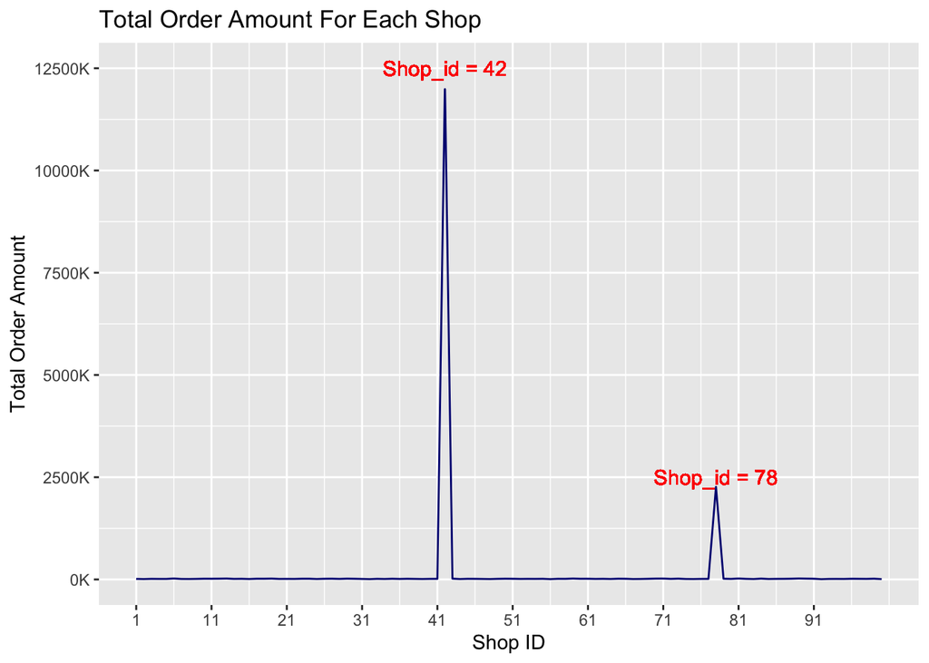

```r
graph_for_order_amount_each_store = ggplot(order_amount_each_store, aes(x = shop_id, y = total_order_amount)) +
  geom_line(col = 'navy') +
  scale_x_continuous(limit = c(1, 100), breaks = seq(1,100,10)) +
  scale_y_continuous(limits = c(0,12500000), breaks = seq(0,12500000, 2500000), labels = function(y){paste0(y/1000, 'K')})+
  labs(title = 'Total Order Amount For Each Shop', x = 'Shop ID', y= 'Total Order Amount')+
  geom_text(x=42, y=12500000, label='Shop_id = 42', size = 4, col = "red")+
  geom_text(x=78, y=2500000, label='Shop_id = 78', size = 4, col = "red")


graph_for_order_amount_each_store
```

- From the tibble and graphs generated above, we can see that shop 42 has the greatest order amount from customers, and shop 78 has the second largest order amount. However, these two shops seem to have too many order amounts that can be outliers in this dataset and affect the accuracy of AOV.

```r
# Checking total number of transactions based on different categories of total_items

total_transactions_on_categories_of_total_items <- shopify_dataset%>%
  group_by(total_items)%>%
  count(total_items)%>% # count the number of transactions for each category of total iteams
  rename(total_transactions = n) # rename the counting column




total_transactions_on_categories_of_total_items
```

```
## # A tibble: 8 × 2
## # Groups:   total_items [8]
##   total_items total_transactions
##         <dbl>              <int>
## 1           1               1830
## 2           2               1832
## 3           3                941
## 4           4                293
## 5           5                 77
## 6           6                  9
## 7           8                  1
## 8        2000                 17
```

- It is interesting to see that most of the transactions are under 8 total items, but there are still 17 transactions that have 2000 total_items. We should explore those 17 transactions further in order to check if this is the reason that affects the calculation of AOV.

```r
extreme_total_items <- shopify_dataset%>%
  filter(total_items == 2000) # filter out rows that only has total items equal to 2000


extreme_total_items
```

```
## # A tibble: 17 × 7
##    order_id shop_id user_id order_amount total_items payment_method created_at
##       <dbl>   <dbl>   <dbl>        <dbl>       <dbl> <chr>          <chr>
##  1       16      42     607       704000        2000 credit_card    2017-03-07 …
##  2       61      42     607       704000        2000 credit_card    2017-03-04 …
##  3      521      42     607       704000        2000 credit_card    2017-03-02 …
##  4     1105      42     607       704000        2000 credit_card    2017-03-24 …
##  5     1363      42     607       704000        2000 credit_card    2017-03-15 …
##  6     1437      42     607       704000        2000 credit_card    2017-03-11 …
##  7     1563      42     607       704000        2000 credit_card    2017-03-19 …
##  8     1603      42     607       704000        2000 credit_card    2017-03-17 …
##  9     2154      42     607       704000        2000 credit_card    2017-03-12 …
## 10     2298      42     607       704000        2000 credit_card    2017-03-07 …
## 11     2836      42     607       704000        2000 credit_card    2017-03-28 …
## 12     2970      42     607       704000        2000 credit_card    2017-03-28 …
## 13     3333      42     607       704000        2000 credit_card    2017-03-24 …
## 14     4057      42     607       704000        2000 credit_card    2017-03-28 …
## 15     4647      42     607       704000        2000 credit_card    2017-03-02 …
## 16     4869      42     607       704000        2000 credit_card    2017-03-22 …
## 17     4883      42     607       704000        2000 credit_card    2017-03-25 …
```

- From the filtered tibble above, we can see that all 17 transactions that have total items of 2000 were made during March and at the exact same time (4:00:00). Furthermore, the user_id and order_amount are also the same for those 17 transactions. One possible reason behind this situation is that someone is using a bot to stockpile this type of sneakers and sell for higher price in the future. Another possibility can be that someone accidentally duplicated this transaction many times. On the other hand, this proves our guess at the beginning that shop 42 is the major reason and outlier that cause the AOV to be incorrect.

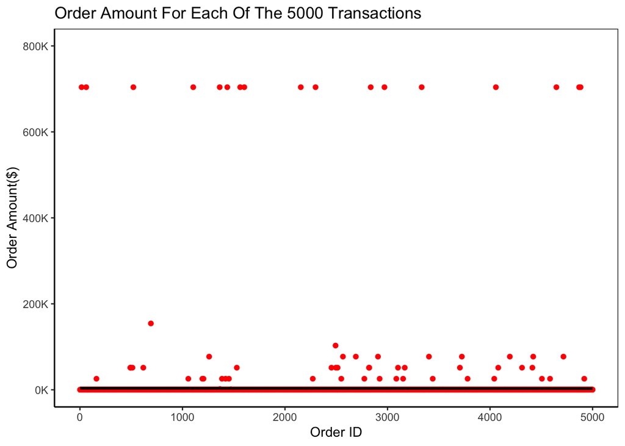

```r
scatterplot_of_order_amount = ggplot(shopify_dataset, aes(x = order_id, y = order_amount)) + geom_point(col = 'red')+
  theme_classic()+
  scale_y_continuous(limits = c(0,800000), breaks = seq(0,800000, 200000), labels = function(y){paste0(y/1000, 'K')})+
  labs(x = 'Order ID', y = 'Order Amount($)', title = 'Order Amount For Each Of The 5000 Transactions')+
  geom_smooth(method=lm, se=FALSE,color="black", fullrange = TRUE)+
  theme(panel.border = element_rect(color = "black", size = 0.5, fill = NA))


scatterplot_of_order_amount
```

- From the scatter plot above, we see that most of the transactions are about hundreds of dollars, and those outliers have order amount of over 600,000$. Those outliers certainly affected the calculation of AOV.

```r
median(shopify_dataset$order_amount)
```

```
## [1] 284
```

```r
#mean(shopify_dataset$order_amount)
```

- In this case, AOV is strongly affected by outliers. On the other hand, median would be a better metric to evaluate this data, because median, unlike mean, would be less affected by outliers.